# Part II - San Francisco - Bay Area Bike Share

## by Jason Kannemeyer

## Investigation Overview

> My investigation in this project focused on how trip duration varies depending on the day/month and time of trip, as well as the influence of membership type and bike type.

### Key insights

> - Rides seems to be higher during the normal morning traffic rush hours, and flattens during the day but picks up again later at night when people return from work.
> - Casual drivers seems to last longer then that of members, even though the number of members are more than that of casual drivers
> - I also found that the number of bikes does not necesarily mean the durations will be longer, because what I saw from the comparison between the types of bikes - even though Docked bikes only accounts for 10.087% of the total bikes, their trip durations are higher then that of the bikes with higher numbers
> - From the data that I used you can see that people tend to use the service more on Saturday and Sunday, and October seems to be the time when more trips are recorded then any other month - could be because of tourists traveling more to the bay area in October.

## Dataset Overview

> Bay Area Bike Share began in August 2013 and features a fleet of 700 bicycles and 70 stations along the San Francisco peninsula. Specially designed, durable bikes are locked into a network of docking stations and can be rented from and returned to any station in the system. The bike share system operates year-round, 24 hours a day, with stations in San Francisco, Redwood City, Palo Alto, Mountain View, and San Jose.

> Bike sharing allows Bay Area residents and visitors an additional, cost-effective transportation option. It offers many public health benefits, such as reducing the amount of harmful vehicle emissions released into the air. The program’s network is efficiently linked to public transit and numerous docking stations, providing many possible route combinations.

> Since January 1, 2016, the Metropolitan Transportation Commission has been in charge of overseeing the Bay Area Bike Share Program.

> My Analysis will focus on data from 2020 - 2022, 202205 dataset it gives errors and even with error checking The data is still in a non readable format - All data from 201801-202003 is excluded since the dataset columns are not the same format and number of columns

## PIE Chart - Bike Types

> In the chart I want to make the users focus on the types of bikes available for use by the bike service - we tend to make deductions based of off a chart simply based on the numbers presented to us, even from the below chart we can see that electric bikes have the largest number of available bikes, with Docked bikes being the lowest - so we can assume the avarage duration would be highest on electric bikes

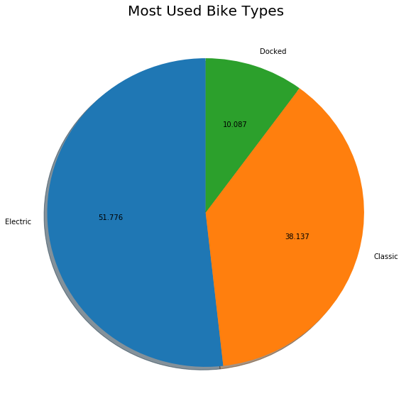

## Pointplot - Bike Types vs Weekday

> Continuing from the above pie chart - clarifying our initial assumptions that Electric Bikes would have on average more trips because it has more bikes then all the other bikes combined - but we see in the below grpah that we could not be more further from the truth because docked bikes on avaerage has higher duration times then electric bikes and electric bikes in terms of average duration records the lowest number of trips(duration) then the rest of the bikes

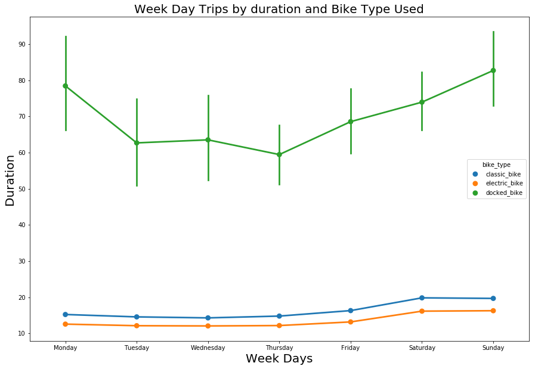

## Countplot - Months with highest trip count

> It seems that during the winter months Dec-Feb less people make use of the service, which is expected since people don't want to get trapped in snow on a bike or get caught in the rain as oppossed to the summer months June-Aug. October seems to be the clear winner, one of the reasons seems to be tourists and events taking place that month - In the fall, temperatures begin to cool down around the country. This is a welcome season in northern regions, where leaves change to beautiful shades of red, yellow and orange.
> - https://www.holidify.com/pages/san-francisco-in-october-5283.html

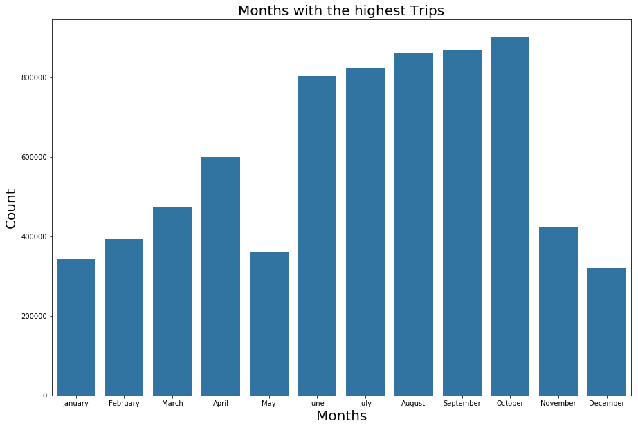